# LINEAR MODELS IN LEARNING STATISTICS

J. Camilo Fagua and Patrick Jantz

March 2024

# **Objectives**

1. Review and refresh our memory about the classic linear regression modeling.
2. Understand the linear regression models in the context of the learning statistics.
3. Understand the importance of the tuning in some linear regression models
4. Learn to predict spatially a linear regression model.

# **1) Introduction**

This tutorial is about simple linear regression (LR) and LR-extensions applied in learning statistics. LR can serve as a good jumping-off point for newer learning linear approaches that can be seen as generalizations of LR. Consequently, the importance of having a good understanding of LR before studying more complex learning methods cannot be underestimate. Earlier starting the reading about linear regressions, we are going to load some libraries to develop this tutorial.

```r
# To clean environment
#rm(list = ls(all.names = TRUE))
#gc()

#To install packages
#install.packages("usdm")
#install.packages("glmnet")
#install.packages("caret")
#install.packages("earth")


#To open libraries
library("corrplot")
library("usdm")
library("glmnet")
library("caret")
library("earth")
library("dplyr")
library("raster")
library("terra")
library("ggplot2")
```

# **2) Linear Regressions**

# **2.1) Simple Linear Regression (LR)**

LR lives up to its name; it is a very straightforward simple linear approach for predicting a quantitative response variable (Y) using a simple predictor variable (X), assuming that there is approximately a linear relationship between X and Y. Mathematically, all of us know this linear relationship:

$$Y \sim \beta_0 + X\beta_1$$

**($\sim$ means “is approximately modeled as”)**

Where $\beta_0$ and $\beta_1$ are two unknown constants that represent the intercept (the expected value of Y when X = 0) and slope (the average increase in Y associated with a one-unit increase in X) in the linear model. Together, $\beta_0$ and $\beta_1$ are known as the model coefficients or parameters. We can use training data to produce estimates of $\beta_0$ and $\beta_1$ for predicting Y. That is,

($X_1$,$Y_1$), ($X_2$,$X_2$),…, ($X_n$,$Y_n$)

Where n represents observation pairs, each of which consists of a measurement of X and a measurement of Y. The most common LR-approach to estimate these coefficients involves the minimizing of the least square criterion. The first goal under this approach is to obtain coefficient estimates of $\beta_0$ and $\beta_1$ such as, Y $\sim$ $\beta_0$ + $X\beta_1$. In other words, we want to find an intercept ($\beta_0$) and a slope ($\beta_1$) such that the resulting line is as close as possible to the Y data (Hastie et al. 2017).

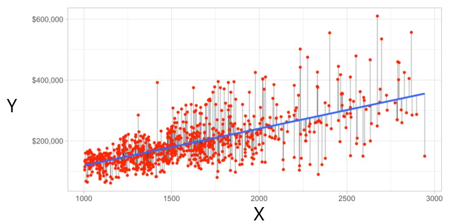

**Figure 1**. Fitted regression line using least square criterion. Grey lines show the vertical distance between the observed (red dots) and predicted (blue line) values (Boehmke and Greenwell 2019)..

Let Y $\sim$ $\beta_0$ + $X\beta_1$ + $e_i$ be the prediction for Y based on the i value of X. Where $e_i$ = $Y_i$ - $Y_ipredic$ represents the i residual o error (the difference between the i observed value and the i response value that is predicted by the linear model). Consequently, we can define the Residual Sum of Squares (RSS) as

RSS = $e_1$ + $e_2$ + $e_n$

or equivalently as (if we clear $e_i$ from the equation)

RSS = $(Y_1 - \beta_0 - \beta_1 X_1)^2$ + $(Y_2 - \beta_0 - \beta_2 X_2)^2$ + $(Y_n - \beta_0 - \beta_n X_n)^2$

The least squares criterion approach chooses $\beta_0$ and $X\beta_1$ minimizing RSS by applying next calculus, which defines the least square coefficients for the simple linear regression as

$$\beta_1 = \frac{\sum_{i=n}^{n}{(X_i - X)(Y_i-Y)}}{\sum_{i=n}^{n} {(X_i -
X)^2}}$$

$$\beta_0 = Y - X\beta_1$$
Where X and Y are the simple means of the data pairs (Hastie et al. 2017).

The true relationship between Y and X is generally not known for real data (the population regression line is unobserved), but the coefficient estimates ($\beta_0$ and $\beta_1$) can be always used to approximate a linear function as we described previously. Now, we are going to assume that we know the true population regression function.

$$f(X) = 2+3X$$

This function does not have error (e) because we are assuming that this is the true relationship between Y and X. Therefore, we can simulate a true data-set applying the function f(X) = 2+3X

```r
set.seed(12) # To repeat the same random generations of numbers.
x = runif(1000, min=-2, max=2) # To generate X data with a uniform distribution. Uniform distribution refers to a type of probability distribution in which all outcomes are equally likely.
y_true = 2+(3*x) # To apply the true function and X data for estimating true-Y.
df_true = data.frame(x, y_true) # The true data-set of 1000 pairs Y and X.
names(df_true) = c("x","y")
head(df_true, n=10)
```

```
##             x          y
## 1  -1.7225563 -3.1676690
## 2   1.2711008  5.8133024
## 3   1.7704869  7.3114608
## 4  -0.9224725 -0.7674175
## 5  -1.3226075 -1.9678225
## 6  -1.8644175 -3.5932525
## 7  -1.2848600 -1.8545799
## 8   0.5666615  3.6999844
## 9  -1.9084890 -3.7254671
## 10 -1.9667007 -3.9001021
```

We can also simulate data with deviations (error-e) to the true function by adding errors to the previous X data using the function rnorm(), which is a generator of random data with normal distribution. The errors must follow the normal distribution and be independent of X because these are requirements for LR analysis.

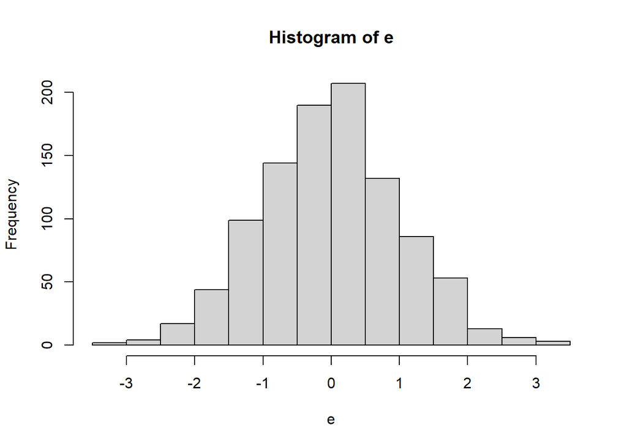

```r
e = rnorm(n=1000, mean=0, sd=1)
hist(e) # Histogram to observe the normal distribution of the errors.  to observe the normal distribution of the errors.
```

```r
df_observed= data.frame(df_true$x, df_true$y+e) # The data-set of 1000 pairs Y and X with errors.
c("x","y")
```

```
## [1] "x" "y"
```

From the dataset with errors, we can create three sets of 40-observed data (datasets with errors). These are the type of data that we usually have in our analyses, and we are going to called them observed datasets A, B and C.

```r
df_observed_A = df_observed[sample(nrow(df_observed), 40), ]
names(df_observed_A) = c("x","y")
df_observed_B = df_observed[sample(nrow(df_observed), 40), ]
names(df_observed_B) = c("x","y")
df_observed_C = df_observed[sample(nrow(df_observed), 40), ]
names(df_observed_C) = c("x","y")
```

We can also plot and compare the LRs generated by the least squares criterion approaches of the three observed datasets and the true function f(X) = 2+3X. Notice that LRs of the observed datasets (generated using the same error function) resulted in slightly different least squares lines. Also, notice that the LRs of observed datasets are different to the LR of the true function; LRs of the observed datasets are biased, that is, they may overestimate or underestimate Y.

```r
TABLA_1 = rbind(df_true, df_observed_A, df_observed_B, df_observed_C)
TABLA_1$LR = c(rep("df_true",1000),rep("df_observed_1",40), rep("df_observed_2",40),rep("df_observed_3",40) )
head(TABLA_1)
```

```
##            x          y      LR
## 1 -1.7225563 -3.1676690 df_true
## 2  1.2711008  5.8133024 df_true
## 3  1.7704869  7.3114608 df_true
## 4 -0.9224725 -0.7674175 df_true
## 5 -1.3226075 -1.9678225 df_true
## 6 -1.8644175 -3.5932525 df_true
```

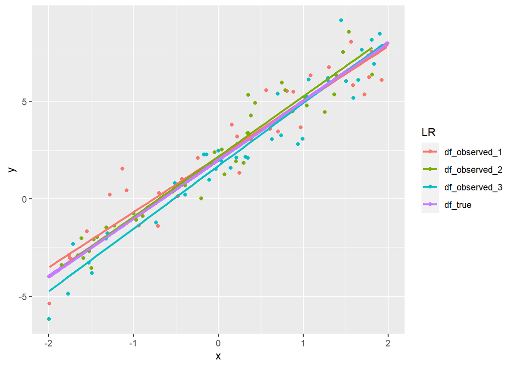

```r
#
ggplot(TABLA_1, aes(x=x, y=y, colour=LR)) +
  geom_point() +
  geom_smooth(se = F, method = lm)
```

Bias is a main problem in LR and other statistical analyses (Bivand et al. 2013). If we assume only one dataset of observed data, the LR will be biased (it will under or over-estimated Y). But if we could average many LRs of observed datasets, the resulted LR-mean ($\mu$) would be closer to the LR of the true function. But how accurate is $\mu$ as an estimate of an observed LR ($\mu1$)? We answer this question by computing the standard error of $\mu$, written as SE($\mu1$). We have the next formula:

$$var(\mu1) = SE(\mu1)^2 = \sigma^2/n$$

Where $\sigma$ is the standard deviation of each of the realizations $Y_n$ of Y. Roughly speaking, this standard error tells us the average amount that this estimate $\mu1$ differs from the actual value of $\mu$. This standard deviation $\sigma$ is not known but can be approximate from the data. This approximate estimation is known as the Residual Standard Error (RSE) and is given by the next formula.

$$RSE = \sqrt{RSS/(n-2)}$$

RSE is used to compute confidence intervals. A 95 % confidence interval is defined as a range of values such that with 95 % interval probability, the range will contain the true unknown value of the parameter. The range is defined in terms of lower and upper limits computed from the observed data (Bivand et al. 2013, Hastie et al. 2017).

Now, we are going to apply the least squares criterion approach using R to a dataset where Y and X are temporal means of EVI (Enhanced Vegetation Index) and NIR (Near Infra-Red) that were estimated using all available imagery clean of clouds between January-2018yr and December-2020yr (Table 1). EVI is calculated based on RED, NIR, and BLUE (Table 1); thus, we can expect a significant linear relation between EVI (response variables or Y) and NIR (the predictor variable or X). These data were acquired with 16-bit integer of spectral resolution (-32768 to 32767) for a study area with low anthropic disturbance in the Colombian Orinoquia (Figure 2). After reading the data, we can observe that we have 20021 EVI and NIR pairs of data to estimate $\beta_0$ and $\beta_1$ coefficients.

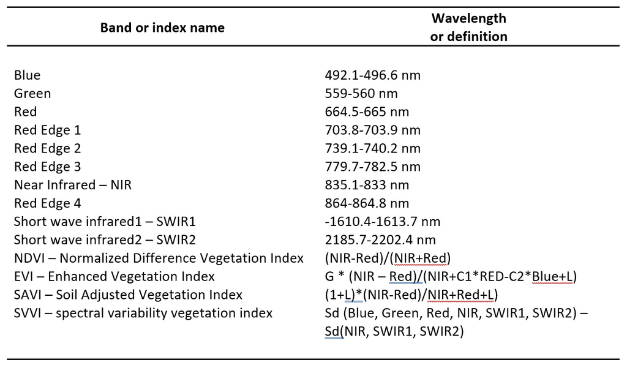

**TABLE 1**. Sentinel-2 variables used to predict Canopy Height (CH).

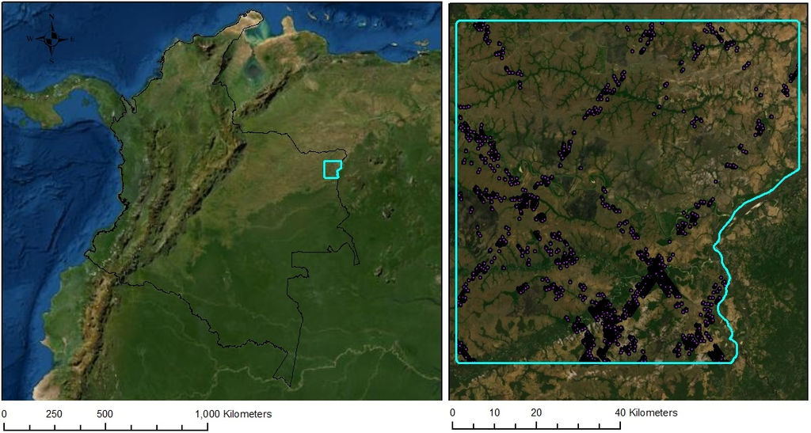

**Figure 2**. Study area and distribution of the data set. (a) Location of study area in Colombia at the RGB band combination of MODIS (2018yr). (b) GEDI data (20,021 footprints; dots in magenta) at the RGB band combination of Worldview (2018yr).

```r
#setwd("")
TABLA = read.csv("DATA_CH_ORINOQUIA_FINAL.csv")
dim(TABLA)
```

```
## [1] 20021    18
```

```r
names(TABLA)
```

```
##  [1] "X_a1"       "Y_a1"       "CH"         "BLUE"       "GREEN"
##  [6] "RED"        "RED_EDGE_1" "RED_EDGE_2" "RED_EDGE_3" "NIR"
## [11] "RED_EDGE_4" "SWIR_1"     "SWIR_2"     "NDVI"       "EVI"
## [16] "SAVI"       "SVVI"       "RNDVI"
```

```r
# To observe the maximum and minimum values of the data.
maxs <- apply(TABLA, 2, max)
maxs
```

```
##        X_a1        Y_a1          CH        BLUE       GREEN         RED
##  -67.671065    5.768883   90.230000 2703.000000 2996.000000 3432.000000
##  RED_EDGE_1  RED_EDGE_2  RED_EDGE_3         NIR  RED_EDGE_4      SWIR_1
## 3814.000000 3891.000000 4274.000000 4163.000000 4610.000000 6116.000000
##      SWIR_2        NDVI         EVI        SAVI        SVVI       RNDVI
## 5761.000000 8903.000000 7140.000000 2720.000000  697.000000 2243.000000
```

```r
mins <- apply(TABLA, 2, min)
mins
```

```
##         X_a1         Y_a1           CH         BLUE        GREEN          RED
##   -68.408957     5.030958     1.760000     0.000000     0.000000     0.000000
##   RED_EDGE_1   RED_EDGE_2   RED_EDGE_3          NIR   RED_EDGE_4       SWIR_1
##     0.000000     0.000000     0.000000     0.000000     0.000000     0.000000
##       SWIR_2         NDVI          EVI         SAVI         SVVI        RNDVI
##     0.000000 -5125.000000 -1116.000000  -535.000000   -92.000000 -1465.000000
```

The function “lm” runs LR analyses. Intercept is the value of $\beta_0$ and NIR indicates $\beta_1$.

```r
#LR1 = lm(TABLA$ EVI ~ TABLA$NIR)
LR1 = lm(EVI ~ NIR, data=TABLA)
coef(LR1)
```

```
##  (Intercept)          NIR
## -2472.050463     2.412925
```

If we type LR1, some basic information about the model is outputted. For more detailed information, we use the function summary(). This gives us the P value (to evaluate if the relation between Y and X fits to the linear model significantly- P values < 0,05) and standard errors for the coefficients (confidence of the coefficients), as well as the $R^2$ statistic and F-statistic for the model. The $R^2$ statistic provides an alternative measure of the model fit. $R^2$ takes the form of a proportion (the proportion of variance explained by the predictor) and so it always takes on a value between 0 and 1, and is independent of the scale of Y. The F-statistic in regression is the result of a test where the null hypothesis is that all the regression coefficients are equal to zero; in other words, the model has no predictive capability. Basically, the F-test compares your model with zero predictor variables (the intercept only model) and decides whether your added coefficients improved the model. If you get a significant result, then whatever coefficients you included in your model improved the model’s fit.

```r
LR1
```

```
##
## Call:
## lm(formula = EVI ~ NIR, data = TABLA)
##
## Coefficients:
## (Intercept)          NIR
##   -2472.050        2.413
```

```r
summary(LR1)
```

```
##
## Call:
## lm(formula = EVI ~ NIR, data = TABLA)
##
## Residuals:
##     Min      1Q  Median      3Q     Max
## -6312.0  -348.2   193.8   626.0  2472.1
##
## Coefficients:
##               Estimate Std. Error t value Pr(>|t|)
## (Intercept) -2.472e+03  2.421e+01  -102.1   <2e-16 ***
## NIR          2.413e+00  1.023e-02   235.9   <2e-16 ***
## ---
## Signif. codes:  0 '***' 0.001 '**' 0.01 '*' 0.05 '.' 0.1 ' ' 1
##
## Residual standard error: 854.3 on 20019 degrees of freedom
## Multiple R-squared:  0.7354, Adjusted R-squared:  0.7354
## F-statistic: 5.564e+04 on 1 and 20019 DF,  p-value: < 2.2e-16
```

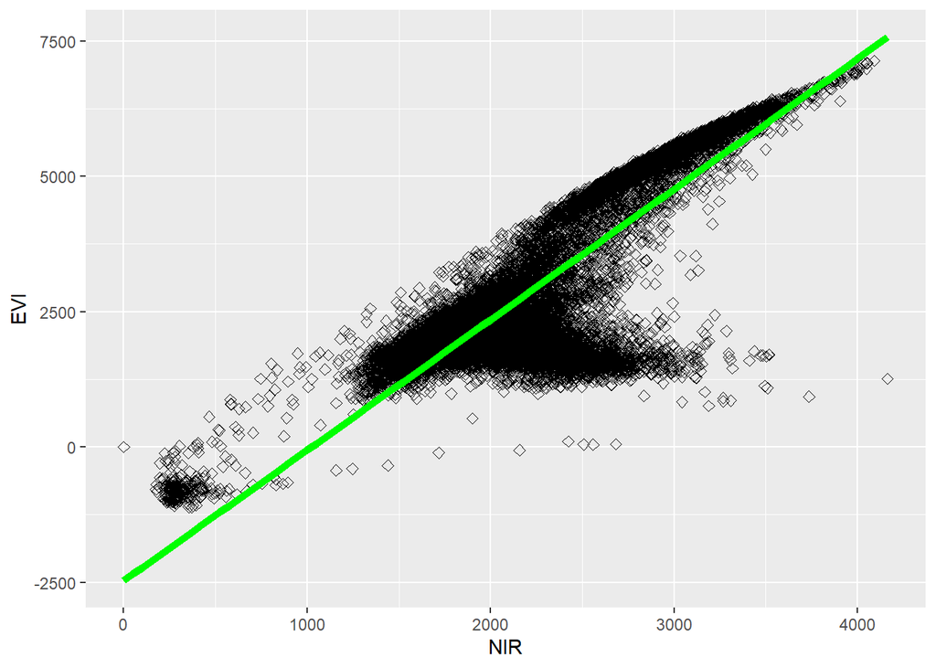

```r
ggplot(TABLA[,c("EVI","NIR")], aes(x=NIR, y=EVI)) +
  geom_point(size=2, shape=23)+
  ylab("EVI")+xlab("NIR")+
  geom_smooth(method=lm, se=FALSE, colour = "green", size=2)
```

# **2.2) Multiple Linear Regression (MLR)**

MLR is the first LR-extensions and allows the use of more than one predictor following the linear model. Of course, MLR is more realistic because we usually analyze multivariate data. MLR can process multiple predictors by giving each predictor a separate slope coefficient in a single model. In general, suppose that we have p distinct predictors; so, MLR model takes the next form.

$$Y = \beta_0 + X1\beta_1 + X2\beta_2 + Xp\beta_p +e$$

where $X_j$ represents the jth predictor and $\beta_j$ quantifies the association between that variable and the response. We interpret $\beta_j$ as the average effect on Y of a one unit increase in $X_j$, holding all other predictors fixed.The coefficients of MLR are estimated using the same least squares approach that we reviewed in the LR. This approach choose $\beta_0$, $\beta_1$,.., $\beta_p$ to minimize the sum of squared residuals.

RSS = $e_1$ + $e_2$ + $e_n$

or equivalently as (if we clear $e_i$ from the equation as we did previously)

$RSS = \sum_{k=0}^{n}(Y_1 - \beta_0 - \beta_1 X_i1 - \beta_2 X_i2 - \beta_p X_ip)^2$

These values of $\beta_0$, $\beta_1$,…,$\beta_p$ are the estimates of the multiple least squares regression coefficients. In general, the other statistics produced by the MLR have a similar interpretation like as the statistics produced by the LR. Even, we use the same function in R, lm(), for running both analyses. However, MLR is an analysis sensitive to the collinearity among the predictors; collinearity refers to the situation in which two or more predictor variables are closely correlated. Collinearity in MLR produces one of the worst problems in statistics, the model can be overfitted if you keep correlated predictors (overfit means that the model seems accurate or with low errors when it is not accurate). Consequently, we need to eliminate correlated predictors before running an MLR (Bivand et al. 2013, Hastie et al. 2017).

```r
names(TABLA)
```

```
##  [1] "X_a1"       "Y_a1"       "CH"         "BLUE"       "GREEN"
##  [6] "RED"        "RED_EDGE_1" "RED_EDGE_2" "RED_EDGE_3" "NIR"
## [11] "RED_EDGE_4" "SWIR_1"     "SWIR_2"     "NDVI"       "EVI"
## [16] "SAVI"       "SVVI"       "RNDVI"
```

```r
TABLA_1 = TABLA[,3:18]
names(TABLA_1)
```

```
##  [1] "CH"         "BLUE"       "GREEN"      "RED"        "RED_EDGE_1"
##  [6] "RED_EDGE_2" "RED_EDGE_3" "NIR"        "RED_EDGE_4" "SWIR_1"
## [11] "SWIR_2"     "NDVI"       "EVI"        "SAVI"       "SVVI"
## [16] "RNDVI"
```

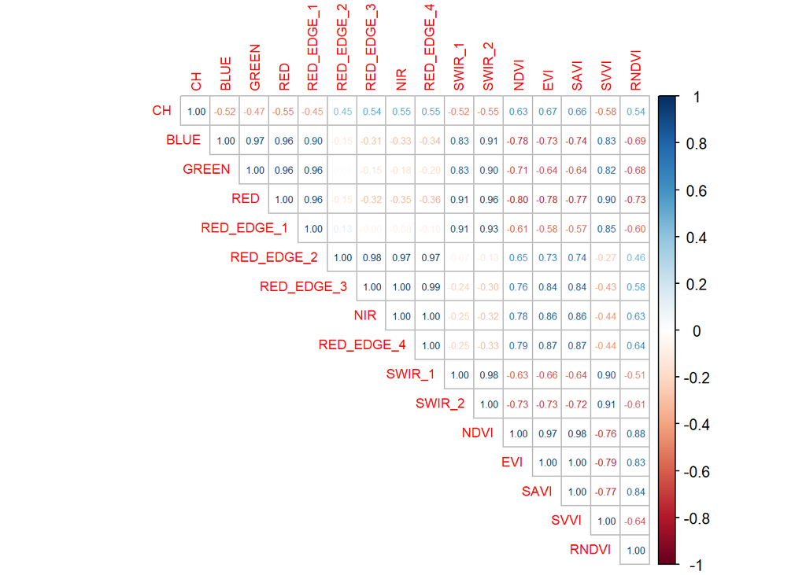

```r
CORRELATIONS = cor(TABLA_1)
corrplot(CORRELATIONS, method = 'number', type = 'upper',
         number.font = 0.05, tl.cex= 0.7, number.cex = 0.5)
```

The plot of correlations shows that some predictors can be significant correlated. To eliminate the collinearity among predictors, we are going to apply a test for multicollinearity based on the Variance Inflation Factor (VIF). The VIF is based on the square of the multiple correlation coefficient resulting from regressing a predictor variable against all other predictor variables. If a variable has a strong linear relationship with at least one other variables, the correlation coefficient would be close to 1. This method can be used to deal with multicollinearity problems when you fit any statistical model. We need to run the function vifcor() of the “usdm” library. This function calculates VIF for a set of variables and excludes the highly correlated variables from the set through a stepwise procedure.

```r
#library(usdm)
var.no.corre = vifcor(TABLA_1[,c(2:16)],th=0.9) # th is the corrleation threshold
var.no.corre
```

```
## 9 variables from the 15 input variables have collinearity problem:
##
## SAVI NIR RED_EDGE_3 SWIR_2 EVI RED_EDGE_2 GREEN RED RED_EDGE_1
##
## After excluding the collinear variables, the linear correlation coefficients ranges between:
## min correlation ( SWIR_1 ~ RED_EDGE_4 ):  -0.2627124
## max correlation ( SVVI ~ SWIR_1 ):  0.8981172
##
## ---------- VIFs of the remained variables --------
##    Variables       VIF
## 1       BLUE  7.076987
## 2 RED_EDGE_4  6.056795
## 3     SWIR_1  7.420735
## 4       NDVI 20.977783
## 5       SVVI  7.307973
## 6      RNDVI  4.849105
```

```r
result.var.no.corre = (var.no.corre@results)
result.var.no.corre
```

```
##    Variables       VIF
## 1       BLUE  7.076987
## 2 RED_EDGE_4  6.056795
## 3     SWIR_1  7.420735
## 4       NDVI 20.977783
## 5       SVVI  7.307973
## 6      RNDVI  4.849105
```

VIF test identified six non-correlated predictors: BLUE, RED_EDGE_4, SWIR_1, NDVI, SVVI, and RNDVI. We must organize a new dataframe with the response variable and the non-correlated predictors.

```r
var.no.correlated.names = as.character(result.var.no.corre[,1]) #names of non-correlated predictors
TABLA.NO.CORRE = data.frame(TABLA$CH,TABLA[,names(TABLA)%in% c(var.no.correlated.names)])
head(TABLA.NO.CORRE)
```

```
##   TABLA.CH BLUE RED_EDGE_4 SWIR_1 NDVI SVVI RNDVI
## 1     2.24 1059       3297   3683 3021  489   660
## 2    20.64  305       3543   1875 8387   80  1234
## 3    19.92  297       3427   1837 8442   86  1206
## 4    19.47  269       3395   1936 8573  131  1133
## 5    12.88  319       3498   1746 8380   36  1166
## 6     3.10  334       3590   1848 8307   49  1129
```

```r
names(TABLA.NO.CORRE) = c("CH", var.no.correlated.names) # To rename better
head(TABLA.NO.CORRE)
```

```
##      CH BLUE RED_EDGE_4 SWIR_1 NDVI SVVI RNDVI
## 1  2.24 1059       3297   3683 3021  489   660
## 2 20.64  305       3543   1875 8387   80  1234
## 3 19.92  297       3427   1837 8442   86  1206
## 4 19.47  269       3395   1936 8573  131  1133
## 5 12.88  319       3498   1746 8380   36  1166
## 6  3.10  334       3590   1848 8307   49  1129
```

Now, we can run the MLR using the function lm(). The summary() function indicates: 1) CH presents a significant linear relation to the six predictors (p-value: < 2.2e-16). 2) Each predictor contributes significantly (p-values of t < 0.05). 3) The adjusted R-squared (explained variance) shows that 46% of the CH variance is explained by the predictors.

```r
MLR1 = lm(CH~. ,data=TABLA.NO.CORRE)
MLR1 # To see the coefficients
```

```
##
## Call:
## lm(formula = CH ~ ., data = TABLA.NO.CORRE)
##
## Coefficients:
## (Intercept)         BLUE   RED_EDGE_4       SWIR_1         NDVI         SVVI
##   2.8033224   -0.0047972    0.0059023   -0.0026315   -0.0005506   -0.0051980
##       RNDVI
##   0.0028340
```

```r
summary(MLR1)
```

```
##
## Call:
## lm(formula = CH ~ ., data = TABLA.NO.CORRE)
##
## Residuals:
##     Min      1Q  Median      3Q     Max
## -18.506  -1.688  -0.525   1.176  85.821
##
## Coefficients:
##               Estimate Std. Error t value Pr(>|t|)
## (Intercept)  2.803e+00  3.212e-01   8.729  < 2e-16 ***
## BLUE        -4.797e-03  6.490e-04  -7.391 1.51e-13 ***
## RED_EDGE_4   5.902e-03  1.646e-04  35.862  < 2e-16 ***
## SWIR_1      -2.632e-03  1.351e-04 -19.477  < 2e-16 ***
## NDVI        -5.506e-04  8.046e-05  -6.843 7.96e-12 ***
## SVVI        -5.198e-03  6.972e-04  -7.455 9.32e-14 ***
## RNDVI        2.834e-03  3.014e-04   9.404  < 2e-16 ***
## ---
## Signif. codes:  0 '***' 0.001 '**' 0.01 '*' 0.05 '.' 0.1 ' ' 1
##
## Residual standard error: 5.891 on 20014 degrees of freedom
## Multiple R-squared:  0.4674, Adjusted R-squared:  0.4672
## F-statistic:  2927 on 6 and 20014 DF,  p-value: < 2.2e-16
```

# **2.3) MLR in the context of learning statistics**

The package “caret” offers the function train to apply MLR in a learning algorithm way. After a five folds cross validation, errors estimates show a relatively admissible errors: 5.8m for RMSE (root-mean-square deviation), 3.2 m for MAE (Mean Absolute Error), and an explained variance of 46%.

```r
MLR1_train = train(CH ~.,
                  data=TABLA.NO.CORRE,
                  method="lm",
                  trControl = trainControl(method = "cv", number=5))

MLR1_train
```

```
## Linear Regression
##
## 20021 samples
##     6 predictor
##
## No pre-processing
## Resampling: Cross-Validated (5 fold)
## Summary of sample sizes: 16016, 16016, 16018, 16017, 16017
## Resampling results:
##
##   RMSE      Rsquared   MAE
##   5.878037  0.4698476  3.216172
##
## Tuning parameter 'intercept' was held constant at a value of TRUE
```

Now, we can open the Sentinel-2 raster predictor for a smaller clip of the study area and select the non- correlated-bands and spectral indices.

```r
Sent_2 = brick("Sent2_mean_156_clip.tif")
```

[output not shown]

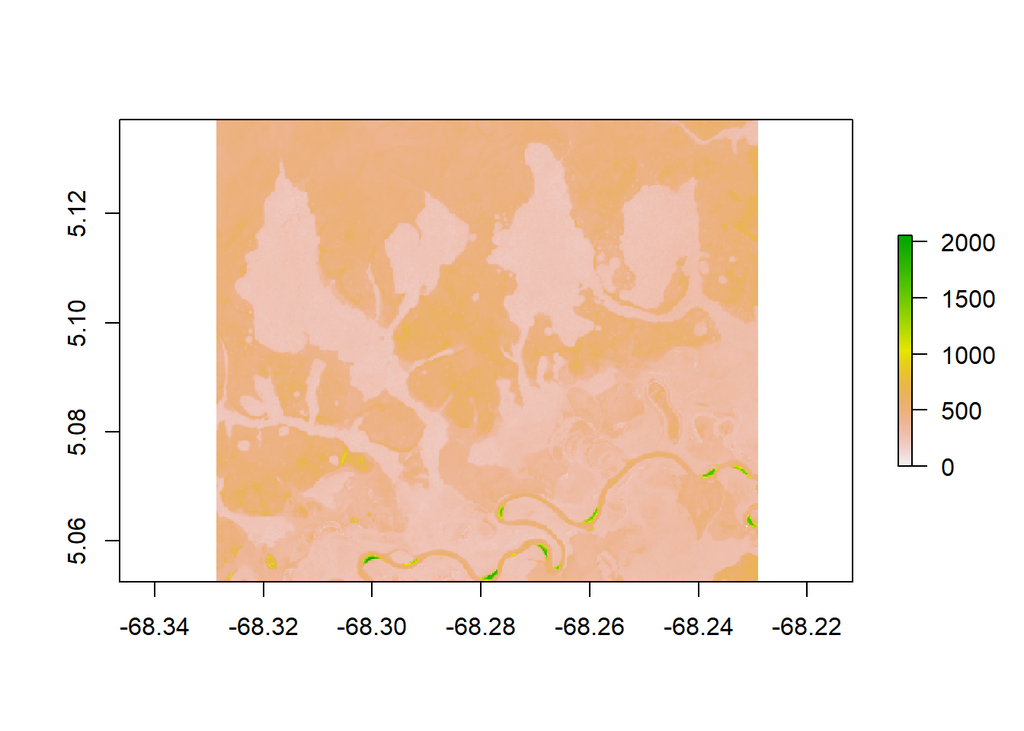

```r
plot(Sent_2[[1]])
```

```r
names(Sent_2) = c("BLUE","GREEN","RED","RED_EDGE_1","RED_EDGE_2","RED_EDGE_3",
       "NIR","RED_EDGE_4","SWIR_1","SWIR_2","NDVI","EVI","SAVI","SVVI", "RNDVI")#To rename the raster bands.

RASTER.PREDICTORS = stack(Sent_2[[var.no.correlated.names]])
RASTER.PREDICTORS
```

```
## class      : RasterStack
## dimensions : 377, 445, 167765, 6  (nrow, ncol, ncell, nlayers)
## resolution : 0.0002245788, 0.0002245788  (x, y)
## extent     : -68.329, -68.22907, 5.052574, 5.137241  (xmin, xmax, ymin, ymax)
## crs        : +proj=longlat +datum=WGS84 +no_defs
## names      :  BLUE, RED_EDGE_4, SWIR_1,  NDVI,  SVVI, RNDVI
## min values :     0,          0,      0, -4248,   -94, -1271
## max values :  2059,       4500,   5642,  8901,   602,  2979
```

```r
names(RASTER.PREDICTORS)
```

```
## [1] "BLUE"       "RED_EDGE_4" "SWIR_1"     "NDVI"       "SVVI"
## [6] "RNDVI"
```

Finally, we can predict the MLR1_train model in the raster predictors to generate a map of the CH for this small clip in the study area.

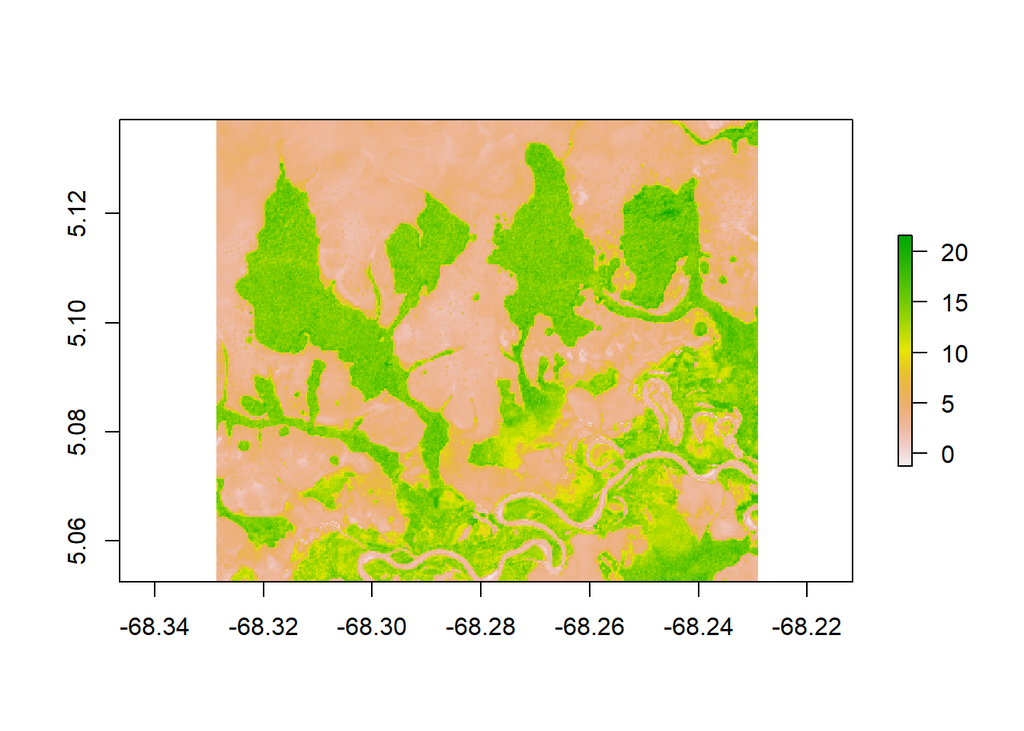

```r
MRL1.MAPA = predict(RASTER.PREDICTORS,MLR1_train)
plot(MRL1.MAPA)
```

```r
#writeRaster(MRL1.MAPA, filename = "MRL1.MAPA.tif", format = "GTiff")
```

# **3) Regularized Regressions**

LR and MLR provide a simple and effective approach to spatial predictive modeling. However, modern spatial datasets normally contain big numbers of predictor variables that break down certain assumptions of LR and MLR, overfitting the training data modeling (such as, constant variance, collinearity, and high numbers of samples and predictors) while increasing the error of the testing data. Regularized methods constrain or regularize the magnitude and variation of the coefficients (the magnitude and fluctuations of coefficients increase with collinearity, number of predictors, and number of samples), which can decrease errors of testing data (the map errors). Regularized methods, also referred as penalized models or shrinkage methods, include a penalty term (P) in the SSE estimation that constrains the size of the coefficients (Boehmke and Greenwell 2019, Kuhn et al. 2019). See the term P in the SEE equation

$$minimize(SSE+P)$$
Ridge Penalty Regression (RPR), Lasso Penalty Regression (LPR), and Elastic Net Regression (ENR) are the three most used regularized regression types: 1) RPR controls the coefficients by adding a Euclidian penalty term called L2 (P in the previous equation) that push the coefficients to zero to reach the regularization. RPR does not perform predictor selection and retain all predictors. 2) LPR is an improve of RPR that modifies L2, producing that the coefficients reach values approximately to zero (but not equal to zero) in the regularization, allowing the elimination of predictors. 3) ENR is considered a generalization of both, RPR and ENR.

We are going to use the library “glmnet” to implement regularized regressions through the function train() of the library “caret”. By running the function train(), we allow caret to choose the tuning parameters for us.

```r
glmnet1_train = train(CH ~.,
                      data=TABLA_1,
                      method= "glmnet",
                      trControl = trainControl(method = "cv", number=5))

glmnet1_train# To see the general results of the model
```

```
## glmnet
##
## 20021 samples
##    15 predictor
##
## No pre-processing
## Resampling: Cross-Validated (5 fold)
## Summary of sample sizes: 16017, 16017, 16018, 16016, 16016
## Resampling results across tuning parameters:
##
##   alpha  lambda      RMSE      Rsquared   MAE
##   0.10   0.01077295  5.667935  0.5069650  2.957862
##   0.10   0.10772948  5.796271  0.4844381  3.117828
##   0.10   1.07729480  5.893642  0.4676513  3.287067
##   0.55   0.01077295  5.669670  0.5066622  2.949466
##   0.55   0.10772948  5.853085  0.4742365  3.198358
##   0.55   1.07729480  5.961015  0.4627295  3.456570
##   1.00   0.01077295  5.679903  0.5048467  2.956862
##   1.00   0.10772948  5.852244  0.4745541  3.200069
##   1.00   1.07729480  6.054909  0.4563147  3.692689
##
## RMSE was used to select the optimal model using the smallest value.
## The final values used for the model were alpha = 0.1 and lambda = 0.01077295.
```

```r
glmnet1_train$bestTune # To select the best parameters.
```

```
##   alpha     lambda
## 1   0.1 0.01077295
```

```r
glmnet1_train$results
```

```
##   alpha     lambda     RMSE  Rsquared      MAE    RMSESD RsquaredSD      MAESD
## 1  0.10 0.01077295 5.667935 0.5069650 2.957862 0.4181625 0.03894963 0.07413835
## 2  0.10 0.10772948 5.796271 0.4844381 3.117828 0.4037314 0.03685683 0.06988794
## 3  0.10 1.07729480 5.893642 0.4676513 3.287067 0.3950293 0.03547301 0.06888135
## 4  0.55 0.01077295 5.669670 0.5066622 2.949466 0.4182900 0.03897805 0.07285677
## 5  0.55 0.10772948 5.853085 0.4742365 3.198358 0.3974367 0.03578168 0.06780879
## 6  0.55 1.07729480 5.961015 0.4627295 3.456570 0.3902331 0.03497139 0.06547211
## 7  1.00 0.01077295 5.679903 0.5048467 2.956862 0.4182177 0.03896293 0.07231838
## 8  1.00 0.10772948 5.852244 0.4745541 3.200069 0.3974000 0.03573342 0.06770586
## 9  1.00 1.07729480 6.054909 0.4563147 3.692689 0.3840466 0.03451728 0.06326874
```

```r
glmnet1_RESULTS = glmnet1_train$results
```

An alpha parameter of zero (alpha = 0) indicates the RPR as the best model while an alpha parameter of one (alpha = 1) indicates that the best is LPR. Alpha values between zero and one (0 < alpha < 1) indicates that ENR is the best model. The tunning shows that the ENR model (alpha = 0.1) with lambda of 0.01 is the best model. Now, we can predict the map of CH using the best parameters.

```r
hyper_grid_glmnet1 <- expand.grid(
  alpha = 0.1,
  lambda = 0.01
)
#

glmnet2_train = train(CH ~.,
                     data=TABLA_1,
                     method="glmnet",
                     metric = "RMSE",
                     tuneGrid = hyper_grid_glmnet1,
                     trControl = trainControl(method = "cv", number=5))

glmnet2_train
```

```
## glmnet
##
## 20021 samples
##    15 predictor
##
## No pre-processing
## Resampling: Cross-Validated (5 fold)
## Summary of sample sizes: 16017, 16017, 16017, 16016, 16017
## Resampling results:
##
##   RMSE      Rsquared   MAE
##   5.668948  0.5066538  2.954193
##
## Tuning parameter 'alpha' was held constant at a value of 0.1
## Tuning
##  parameter 'lambda' was held constant at a value of 0.01
```

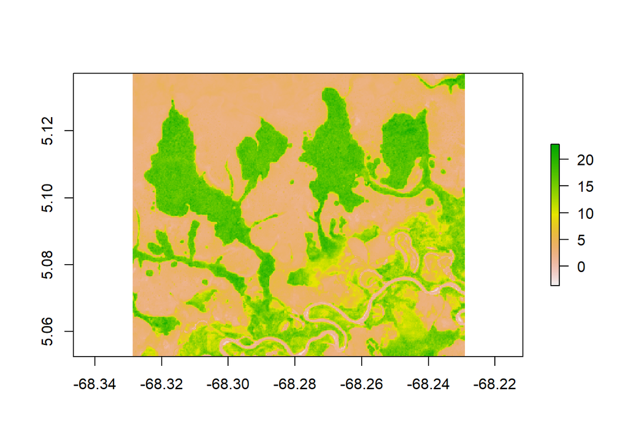

```r
glmnet1.MAPA = predict(Sent_2,glmnet2_train)
plot(glmnet1.MAPA)
```

```r
#writeRaster(glmnet1.MAPA, filename = "glmnet1.MAPA.tif", format = "GTiff")
```

**NOTE: Since regularized methods apply a penalty to the coefficients, we need to ensure our coefficients are on a common scale (that is, predictors need to be in a common scale). If not, the predictors with naturally larger values will be penalized more than predictors with naturally smaller values. By default, glmnet automatically standardizes your predictors (standardize = TRUE); however, when glmnet is used through the “caret” library, predictors cannot be standardized. Our predictors are in the same scale (band or spectral indices in 16bit). If your data have predictors with different units and scales, we recommend the use of the R library ‘standardize’ (function standardize()) before running your data in caret.**

# **4) Multivariate Adaptive Regression Splines - MARS**

The previous linear models presented in this tutorial make a strong assumption about linearity, but this assumption is often poor for many datasets, which can affect predictive accuracy. MARS (Friedman 1991) is an algorithm that creates a piecewise linear model that fit in nonlinear data. MARS provide a convenient approach to capture the nonlinear relationships by assessing cut-points (or knots); points that break the range of data into bins that fit linear relations. Then, the MARS algorithm creates linear models among the knots, selecting the best candidates among the predictors. MARS method to find the knots consist in starting to look for the single point across the range of X values where two different linear relationships between Y and X achieve the smallest SSE (error measure). Then, MARS looks for the next single point cross the range of X values where two different linear relationships between Y and X achieve the second smallest SSE, and so one (Figure 3) (Boehmke and Greenwell 2019, Kuhn et al. 2019, Dalpiaz 2020).

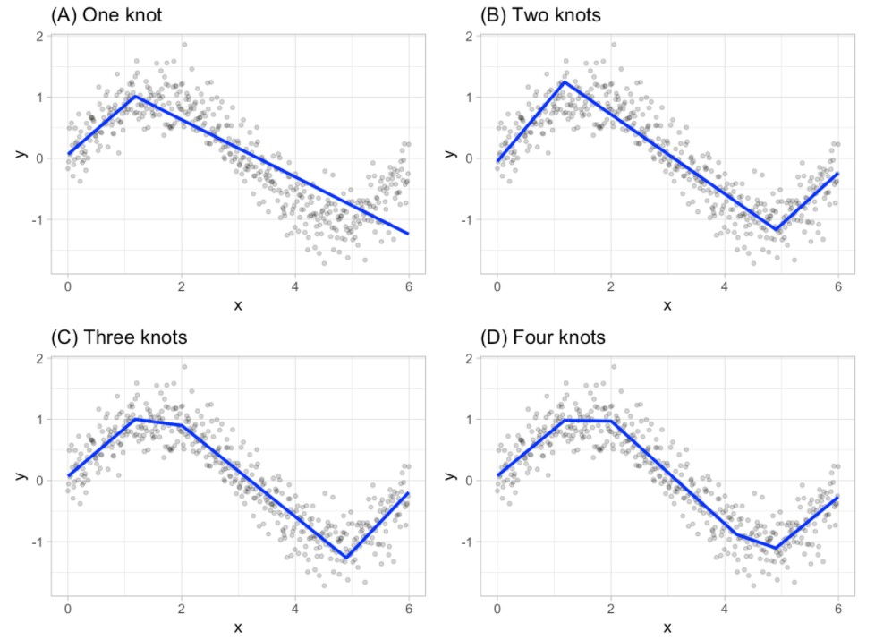

**Figure 3**. Illustration of MARS procedure (A), two (B), three (C), and four (D) knots (Boehmke and Greenwell 2019).

We are going to use the library “earth” to implement MARS through the function train() of the library “caret”. By default, the function earth() will assess all potential knots across all supplied features and then will prune to the optimal number of knots based on an expected change in $R^2$. For MARS in the caret package, we can include information to tune the parameters: 1) degree (potential interactions between different functions; three is the maximum) and 2) nprune (it refers the number of knots to evaluate). Next script is going to take a couple of minutes (no more than 4).

```r
hyper_grid_MARS1 <- expand.grid(
  degree = 1:3,
  nprune = seq(2, 100, length.out = 10) %>% floor()
)

#
MARS1_train = train(CH ~.,
                    data=TABLA_1,
                    method="earth",
                    metric = "RMSE",
                    tuneGrid = hyper_grid_MARS1,
                    trControl = trainControl(method = "cv", number=5))

MARS1_train
```

```
## Multivariate Adaptive Regression Spline
##
## 20021 samples
##    15 predictor
##
## No pre-processing
## Resampling: Cross-Validated (5 fold)
## Summary of sample sizes: 16017, 16017, 16018, 16017, 16015
## Resampling results across tuning parameters:
##
##   degree  nprune  RMSE      Rsquared   MAE
##   1         2     5.830269  0.4780900  2.924648
##   1        12     5.569726  0.5237898  2.782494
##   1        23     5.550647  0.5270447  2.740925
##   1        34     5.550647  0.5270447  2.740925
```

[output cut: 29 more lines]

```r
MARS1_train$bestTune
```

```
##    nprune degree
## 24     34      3
```

```r
MARS1_RESULTS = MARS1_train$results
attach(MARS1_RESULTS)
MARS1_RESULTS = MARS1_RESULTS[order(RMSE),]
MARS1_RESULTS
```

```
##    degree nprune     RMSE  Rsquared      MAE    RMSESD RsquaredSD      MAESD
## 24      3     34 5.525593 0.5314497 2.651837 0.2842704 0.02263415 0.07687105
## 25      3     45 5.525593 0.5314497 2.651837 0.2842704 0.02263415 0.07687105
## 26      3     56 5.525593 0.5314497 2.651837 0.2842704 0.02263415 0.07687105
## 27      3     67 5.525593 0.5314497 2.651837 0.2842704 0.02263415 0.07687105
## 28      3     78 5.525593 0.5314497 2.651837 0.2842704 0.02263415 0.07687105
## 29      3     89 5.525593 0.5314497 2.651837 0.2842704 0.02263415 0.07687105
## 30      3    100 5.525593 0.5314497 2.651837 0.2842704 0.02263415 0.07687105
## 23      3     23 5.531214 0.5305042 2.656616 0.2776172 0.02153377 0.07752204
## 14      2     34 5.535179 0.5297852 2.661702 0.2769836 0.02176057 0.06106008
## 15      2     45 5.535179 0.5297852 2.661702 0.2769836 0.02176057 0.06106008
## 16      2     56 5.535179 0.5297852 2.661702 0.2769836 0.02176057 0.06106008
## 17      2     67 5.535179 0.5297852 2.661702 0.2769836 0.02176057 0.06106008
## 18      2     78 5.535179 0.5297852 2.661702 0.2769836 0.02176057 0.06106008
## 19      2     89 5.535179 0.5297852 2.661702 0.2769836 0.02176057 0.06106008
```

[output cut: 16 more lines]

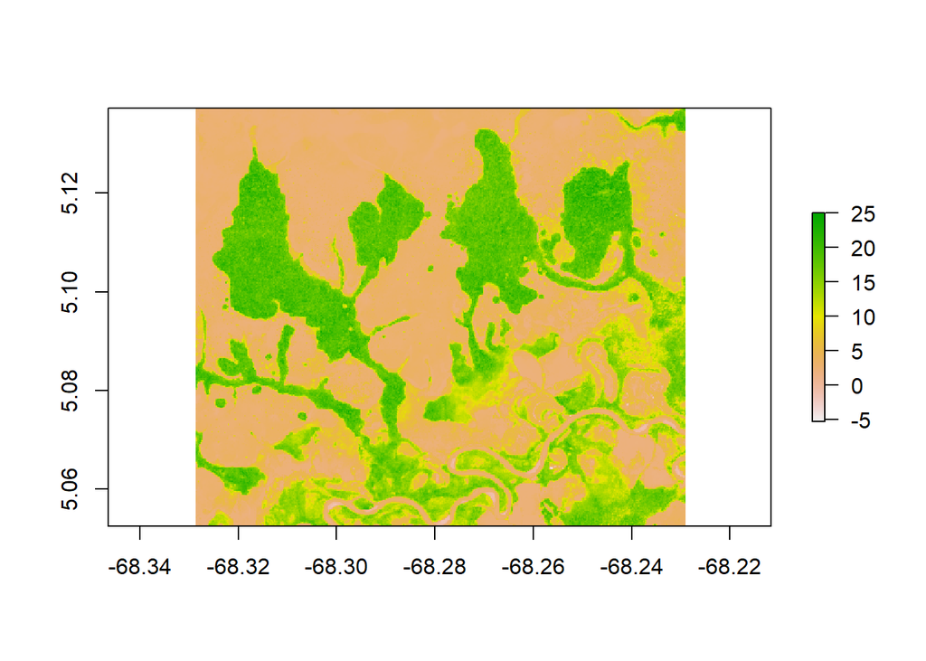

```r
hyper_grid_MARS2 <- expand.grid(
  degree = 2,
  nprune = 34
)


MARS2_train = train(CH ~.,
                     data=TABLA_1,
                     method="earth",
                     metric = "RMSE",
                     tuneGrid = hyper_grid_MARS2,
                     trControl = trainControl(method = "cv", number=5))

MARS2.MAPA = predict(Sent_2, MARS2_train)
plot(MARS2.MAPA)
```

```r
#writeRaster(MARS2.MAPA, filename = "MARS2.MAPA.tif", format = "GTiff")
```

# **LITERATURA CITADA**

Bivand, R., E. Pebesma, and V. Gomez-Rubio. 2013. Applied Spatial Data Analysis with R. Second edition. Springer, New York, US.

Boehmke, B., and B. M. Greenwell. 2019. Hands-On Machine Learning with R. Dalpiaz, D. 2020. R for Statistical Learning.

Hastie, T., R. Tibshirani, and J. Friedman. 2017. The Elements of Statistical Learning: Data Mining, Inference, and Prediction. Page (P. Bickel, P. Diggle, S. Fienberg, U. Gather, I. Olkin, and S. Zeger, Eds.) Springer Series in Statistics. Second Edi. Springer Science+Business Media, New York.

Kuhn, M., J. Wing, S. Weston, A. Williams, C. Keefer, A. Engelhardt, T. Cooper, Z. Mayer, B. Kenkel, M. Benesty, R. Lescarbeau, A. Ziem, L. Scrucca, Y. Tang, C. Candan, and T. Hunt. 2019. Package ‘caret’:Classification and Regression Training. https://github.com/topepo/caret/.